# Coursera - Statistical Inference Project

Nicholas Smith

Friday, July 24, 2015

## Overview

This project will investigate the exponential distribution in R and compare it with the Central Limit Theorem. The exponential distribution can be simulated in R with rexp(n, $\lambda$) where $\lambda$ is the rate parameter.

### 1) Show the sample mean and compare it to the theoretical mean of the distribution.

Consider the mean of the Exponential Distribution is 1/$\lambda$

For this analysis we will be using a lambda value of 0.2

```r
lambda <- 0.2
lambda
```

```
## [1] 0.2
```

Therefore our expected mean will be 5

```r
expected_mean <- 1/lambda
expected_mean
```

```
## [1] 5
```

First we need to simulate some data, we will run a 1000 simulations determining the average of 40 exponentials.

```r
number_samples <- 40
sample_means <- NULL
for (i in 1 : 1000){
  sample_means = c(sample_means, mean(rexp(number_samples, lambda)))
}
```

The centre of our distrubtion is therefore:

```r
sample_mean <- mean(sample_means)
sample_mean
```

```
## [1] 5.027431
```

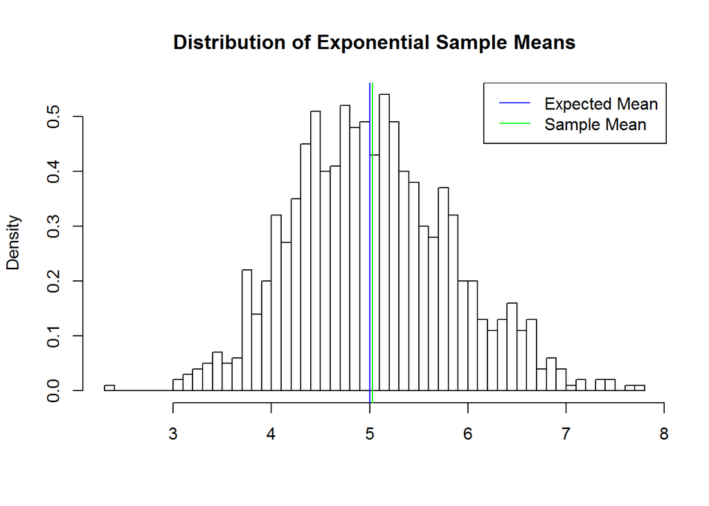

```r
hist(sample_means, breaks=40, prob=TRUE,
     main="Distribution of Exponential Sample Means",
     xlab="")
abline(v=expected_mean, col ="blue")
abline(v=sample_mean, col ="green")
legend("topright", c("Expected Mean", "Sample Mean"),
       col=c("blue", "green"), lwd=1)
```

As we can see with just these 1000 simulations the expected and sample mean are very close.

### 2. Show how variable the sample is (via variance) and compare it to the theoretical variance of the distribution.

The theoretical variance for our distributions is 1/$\lambda$ to the power of 2 divided by the number of observations.

```r
expected_variance <- ((1/lambda)^2)/number_samples
expected_variance
```

```
## [1] 0.625
```

The variance for our sample means is:

```r
sample_variance <- var(sample_means)
sample_variance
```

```
## [1] 0.6574008
```

Although not as close as the means the expected and sample variance are close.

### 3) Show that the distribution is approximately normal

A distribution is considered normal if it meets the following criteria:

- The normal curve is symmetrical about the mean $\mu$
- The mean is at the middle and divides the area into halves
- The total area under the curve is equal to 1
- It is completely determined by its mean and standard deviation $\sigma$ (or variance $\sigma$^2)

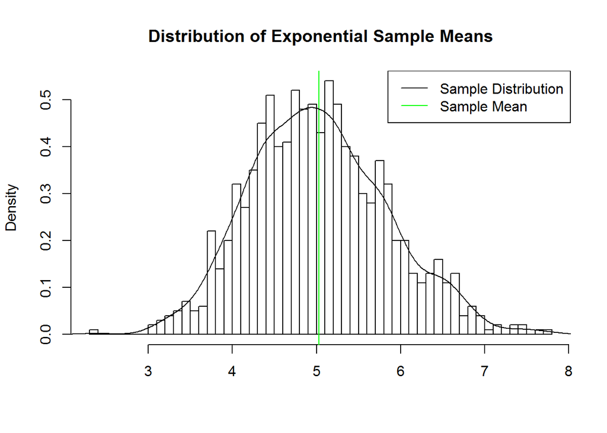

```r
hist(sample_means, breaks=40, prob=TRUE,
     main="Distribution of Exponential Sample Means",
     xlab="")
abline(v=sample_mean, col ="green")
lines(density(sample_means))
legend("topright", c("Sample Distribution", "Sample Mean"),
       col=c("black", "green"), lwd=1)
```

From the above figure above and the answers to questions 1 and 2 we can see that the distribution is approximately normal.